# Use Case 06: Thematic mapping of the geography of a CRT

`CRTspat` is intended to facilitate thematic mapping of the geography of a CRT at each stage from enumeration of the trial population to data analysis. Graphical outputs are generated with `ggplot2()`. In addition there is a function, `CRTwrite()` to export the thematic layers and shapefiles to GIS formats.

The same `plotCRT()` function is used at each stage in the trial (see below), with the functionality available expanding as more fields are populated in the `CRTsp` object. When applied to output from `CRTanalysis()` `plotCRT()` that analyse the spillover interval, an expanded set of thematic maps are available, including overlay plots showing the spillover zone (i.e. the subset of the study area estimated to have effects of spillover) and thematic maps of spatial predictions.

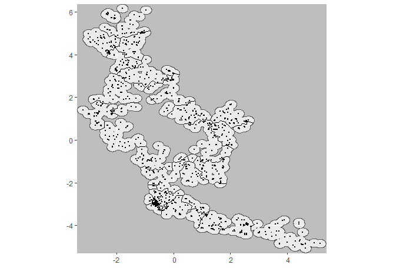

```r
# using the same dataset as for Use Case 1.
library(CRTspat)
exampleCRT <- readdata('exampleCRT.txt')
plotCRT(exampleCRT, map = TRUE, fill = 'none', showLocations=TRUE)
```

*Fig 6.1 Locations*

If the clusters have been established, a map can be drawn showing where they are located. The clusters can be distinguished by colour or by number. To ensure that the image is not too crowded, by default the locations are not shown (but they can be shown if required).

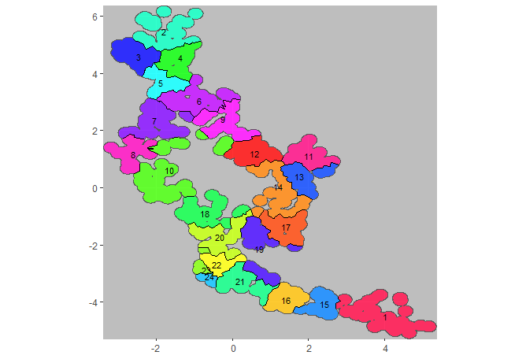

```r
plotCRT(exampleCRT, map = TRUE, fill = 'clusters', showClusterLabels = TRUE, labelsize =3)
```

*Fig 6.2 Clusters*

Similarly, the map of arms is available if the trial has been randomized. Buffer zones can be plotted on this map.

```
## Buffer includes locations within 500m of the opposing arm
```

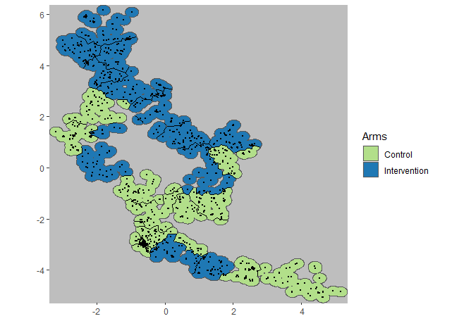

```r
plotCRT(exampleCRT, map = TRUE, fill = 'arms', showLocations=TRUE)
plotCRT(exampleCRT, map = TRUE, fill = 'arms', showBuffer=TRUE,
        showClusterBoundaries = FALSE, buffer_width = 0.5)
```

*Fig 6.3 Arms with locations*

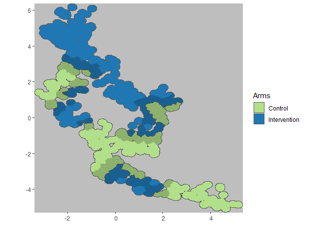

*Fig 6.4 Arms with 500m buffer zone shaded*

Once data have been collected, `plotCRT()` can be used to generate a bar plot to illustrate how much of the data are found close to the boundary between the arms.

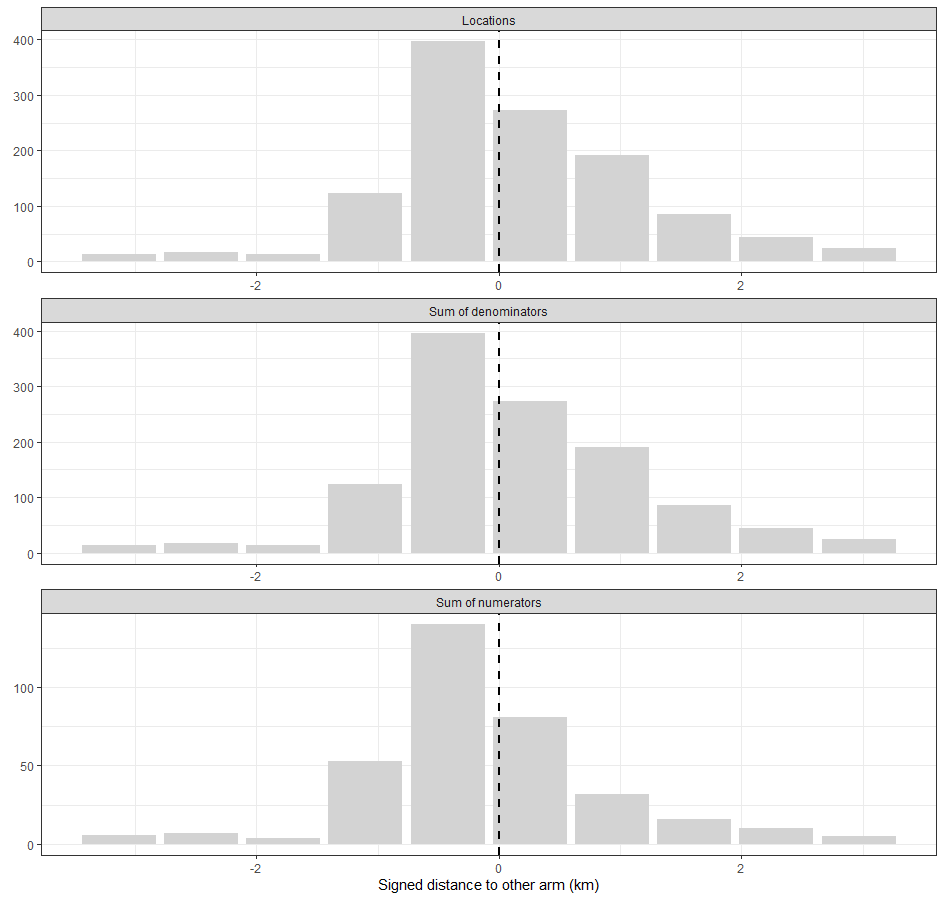

```r
plotCRT(exampleCRT, map = FALSE)
```

*Fig 6.5 Numbers of observations by distance from boundary*

```r
analysis <- CRTanalysis(exampleCRT, cfunc = "P", method = "LME4")
```

```
##
AIC: 1382.59556154402 Spillover scale parameter: 0.21981696975569
```

```
##
AIC: 1385.16678301441 Spillover scale parameter: 1.89442074481204
```

```
##
AIC: 1384.56974564433 Spillover scale parameter: 0.0580687950830108
```

```
##
AIC: 1382.41972768805 Spillover scale parameter: 0.296672334826958
```

```
##
AIC: 1382.21769016816 Spillover scale parameter: 0.435328418519021
```

```
##
AIC: 1382.82566400225 Spillover scale parameter: 0.76341943326029
```

```
##
AIC: 1382.27915707782 Spillover scale parameter: 0.53950586833145
```

```
##
AIC: 1382.21467421951 Spillover scale parameter: 0.450083930258126
```

```
##
AIC: 1382.21584616456 Spillover scale parameter: 0.4653395817005
```

```
##
AIC: 1382.21467421951 Spillover scale parameter: 0.450083930258126
```

```r
summary(analysis)
```

```
##
## =====================CLUSTER RANDOMISED TRIAL ANALYSIS =================
## Analysis method:  LME4
## Link function:  logit
## Measure of distance or surround: Signed distance to other arm (km)
##  with estimation of scale parameter.
## Model formula:  effect + (1 | cluster)
## Error function model for spillover
## Estimates:       Control: 0.417 (95% CL: 0.33 0.509)
##             Intervention: 0.186 (95% CL: 0.136 0.249)
##                 Efficacy: 0.553 (95% CL: 0.331 0.702)
##          Scale parameter: 0.45 (95% CL: 0.45 0.45)
##   Spillover interval(km): 1.749 (95% CL: 1.728 1.762)
## Pr in spillover interval: 0.686 (95% CL: 0.686 0.686)
##    Ipsilateral Spillover: 0.009 (95% CL: 0 0.096)
##  Contralateral Spillover: 0.034 (95% CL: 0 0.122)
## Coefficient of variation: 48.425 (95% CL: 35.969 75.865)
## deviance                :  NA
## AIC                     :  1382.215 including penalty for the spillover scale parameter
```

```
## Buffer corresponds to estimated spillover zone
```

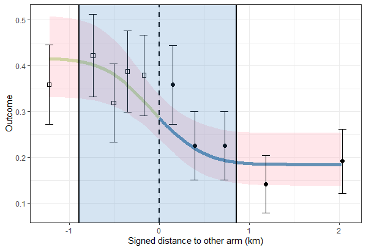

```r
plotCRT(analysis, map = FALSE)
plotCRT(analysis, map = TRUE, fill = 'arms', showBuffer=TRUE, showClusterBoundaries = FALSE)
```

*Fig 6.6 Plot of estimated spillover function*

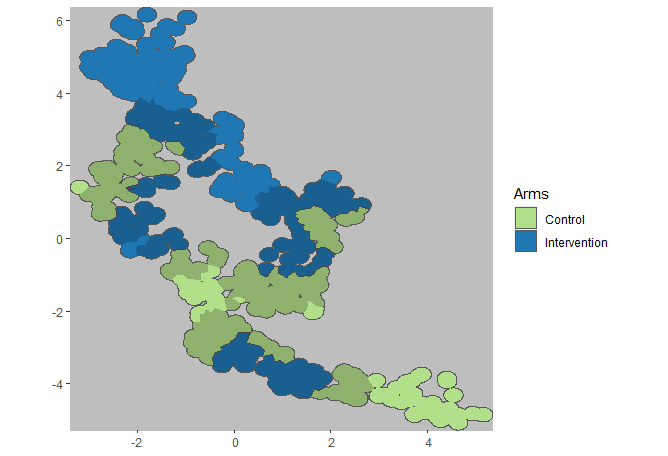

*Fig 6.7 Arms with spillover zone shaded*

## Conclusions

In this example, a large proportion of the data points are close to the boundary between the arms. The analysis (based on simulated spillover) suggests that there are effects of spillover far beyond a 500m buffer. However this does not necessarily mean that the spillover leads to a large bias or loss in power (see Use Case 7).